# Question

By simulating the [Lorenz system](https://en.wikipedia.org/wiki/Lorenz_system), Lorenz made an important contribution to the development of [chaos theory](https://en.wikipedia.org/wiki/Chaos_theory). Below are the rate equations with his original parameters.

$$\begin{align}
\frac{\Delta x}{\Delta t} ~&=~ 10(y-x)\\\\
\frac{\Delta y}{\Delta t} ~&=~ x(28-z)-y\\\\
\frac{\Delta z}{\Delta t} ~&=~ xy-\frac{8}{3}z
\end{align}$$

Use Euler’s method with $\Delta t=0.02$ for time $t=0$ to $t=10$. Graph $x$, $y$, and $z$ as functions of time, using the initial conditions below:

$$x_0 = 5.9$$
$$y_0 = 6.8$$
$$z_0 = 18.5$$

Determine which graph best matches your graph.

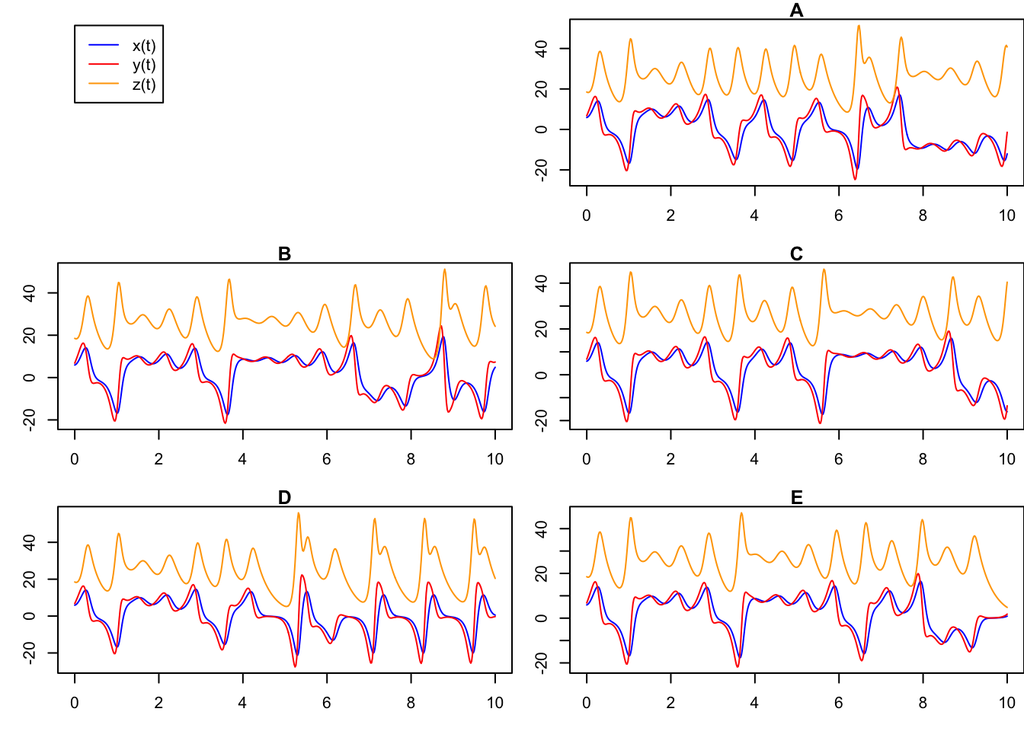

## Answerlist

- A
- B
- C
- D
- E

# Solution

The best graph is **C**.

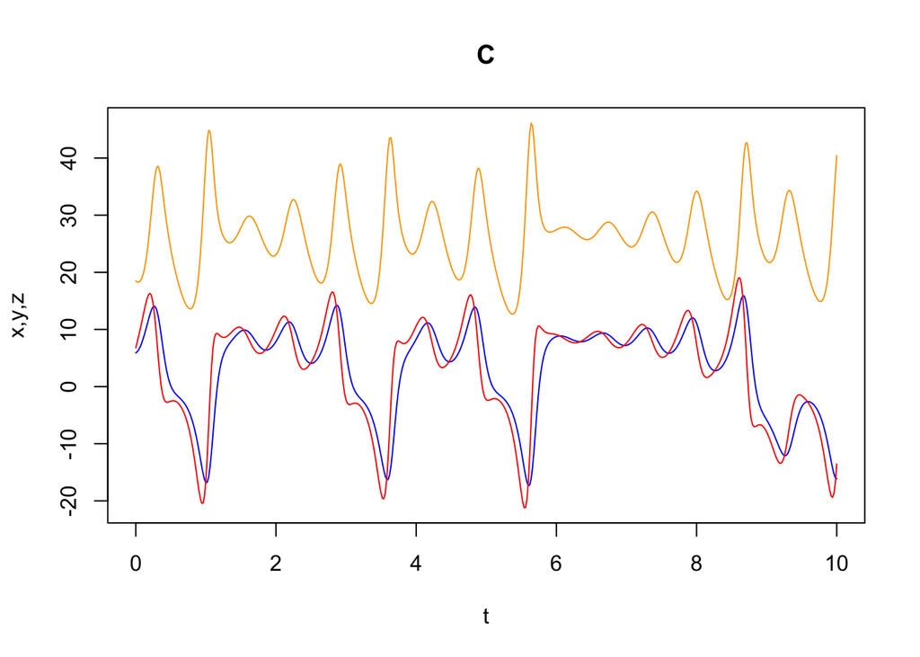

The incorrect graphs start out looking quite similar. All the graphs are using the same rate equations. However, the wrong graphs use initial values that are off by $\pm 0.01$ of the correct initial values. So, as time progresses, the graphs diverge. This phenomenon of slightly different initial conditions producing vastly different outcomes in the long run is called the [butterfly effect](https://en.wikipedia.org/wiki/Butterfly_effect).

From Henri Poincare (1903, translated):

“If we knew exactly the laws of nature and the situation of the universe at the initial moment, we could predict exactly the situation of that same universe at a succeeding moment. But even if it were the case that the natural laws had no longer any secret for us, we could still only know the initial situation approximately. If that enabled us to predict the succeeding situation with the same approximation, that is all we require, and we should say that the phenomenon had been predicted, that it is governed by laws. But it is not always so; it may happen that small differences in the initial conditions produce very great ones in the final phenomena. A small error in the former will produce an enormous error in the latter. Prediction becomes impossible, and we have the fortuitous phenomenon.”

For fun, you can also plot $z$ vs $x$ to graph the Lorenz attractor.

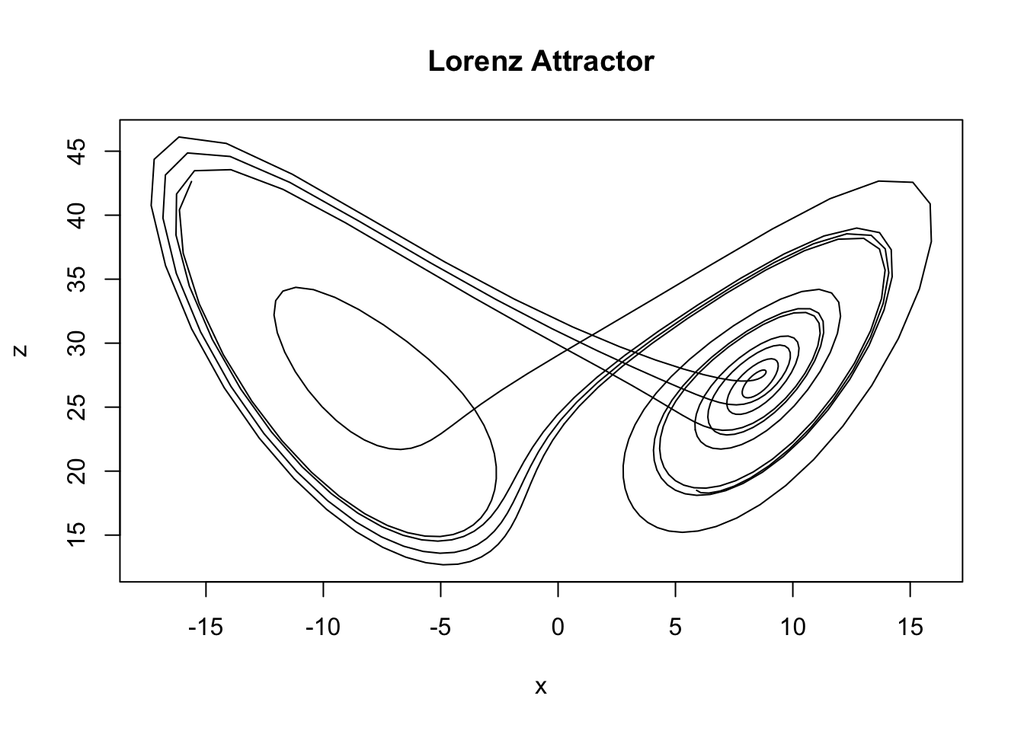

# Meta-information

extype: schoice exsolution: 00100 exname: eulers_method_lorenz